# Lab 08: Modeling Data 1

```r
critical_mc
```

```
##          5%
## -0.01320198
```

```r
slope_observed
```

```
##      s.sidi
## -0.02437131
```

```r
#Now we want percentage of our distribution that is less than or equal to our observed slope value.
n_less = sum(result_mc <= -0.02437131)
n_less
```

```
## [1] 25
```

```r
n_less/10000
```

```
## [1] 0.0025
```

#Q19-20

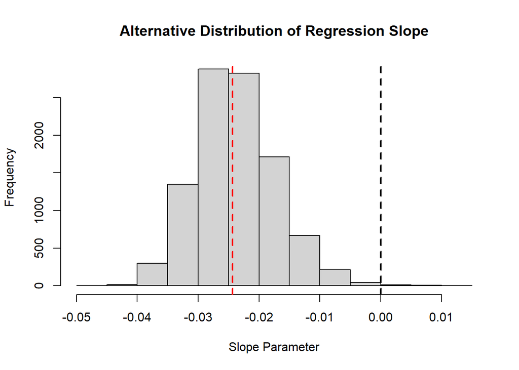

```r
#Q18 (2 pts.): Show the code you used in your bootstrap loop.

#Bootstrapping loop code for repeating the process many times (similar to Monte Carlo loop) in order to simulate the alternative distribution

#Use numeric to create a vector to hold the results
m = 10000
result_boot = numeric(m)

for(i in 1:m)
{
  index_1 = sample(nrow(dat_1), replace = TRUE)

  dat_resampled_b =
  data.frame(
    b.sidi = dat_1$b.sidi[index_1],
    s.sidi = dat_1$s.sidi[index_1]
  )

fit_bs1 = lm(b.sidi ~ s.sidi, data = dat_resampled_b)

  result_boot[i] = coef(fit_bs1)[2]
}

hist(
  result_boot,
  main = "Alternative Distribution of Regression Slope",
  xlab = "Slope Parameter")
abline(v = slope_observed, lty = 2, col = "red", lwd = 2)
abline(v = 0, lty = 2, col = 1, lwd = 2)
```

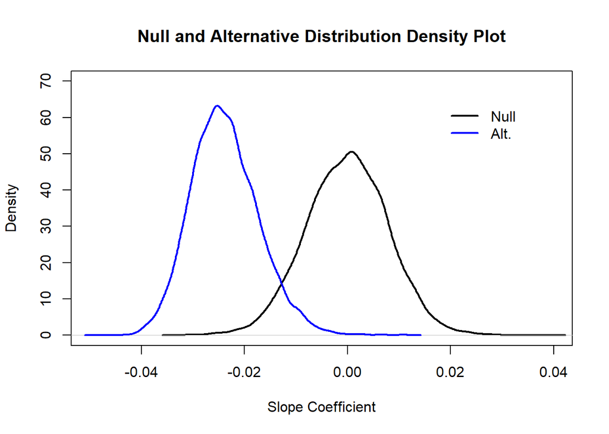

```r
#Q19 (4 pts.): Include your double density plot.

plot(
  density(result_mc),
  main = "Null and Alternative Distribution Density Plot",
  xlab = "Slope Coefficient",
  xlim = c(-0.05, 0.04),
  ylim = c(0, 70),
  col= "black",lwd=2)

lines(
  density(result_boot),
  col = "blue", lwd=2)

legend(
  x="topright",
  bty="n",
  legend=c('Null', 'Alt.'),
  col=c("black", "blue"), lwd=2, inset=c(.1,.1))
```

#Q20 (2 pts.): Recall that the bootstrap curve shows the distribution of plausible values for the slope coefficient if we could resample the original data. The Monte Carlo curve shows the distribution of plausible values for the slope coefficient if the null hypothesis were true. How can you interpret the region that falls under both curves?

#The region that falls under both curves represents the error rates. This area includes both the Type II and Type I error rates, or the probability of failing to reject the null hypothesis when it should be rejected and the probability of rejecting the null hypothesis when in fact it should be accepted (ie nothing interesting is actually going on but we decide it is).